## Report: act_report

# INSIGHTS FROM THE WE RATE DOG TWEETER PAGE ANALYSIS

Historical data about dog ratings tweets from the 'we rate dogs' twitter page were gathered through their tweets archive and twitter api, it was then cleaned, tidied and saved as a master dataset with the most relevant information about each tweet, the dog featured in them, the dog's rating and tweet engagement between november 2015 and august 2017 in a well detailed format.

An analysis was then run on the wrangled data which produced the following insights:

**Insight 1**: The most tweeted about, or in other words the most popular dog breeds in the we rate dog's page are golden_retriever, Labrador_retriever, Pembroke and Chihuahua. These dog breeds were also the most liked, retweeted and highly rated breeds.

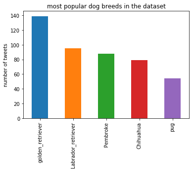

**Insight 2**: The most engaging tweets were tweeted between 11pm to 1am at night and 3pm to 6pm in the evening. 77% of the 100 most liked tweets were tweeted within this hours of the day.

**Insight 3**: The dog stage 'doggo' is the most common dog stage among the most liked tweets

**Insight 4**: There is a positive correlation between tweets likes count and retweet count, as displayed in the scatter plot below

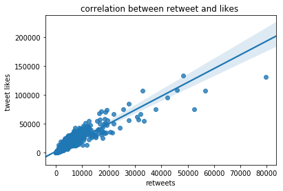

**Insight 5**: There is a slight postive correlation between tweet likes and rating

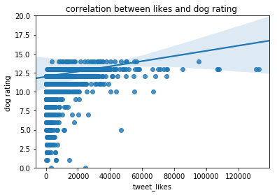

[output not shown]

**Finally** The dog with the best performing tweet in terms of likes, retweet and rating ranking was a black and white standard poodle named BO in the doggo stage and was tweeted about in january 2017 at about 2am. It had over 95000 likes, over 42000 retweets and a rating of 14/10.

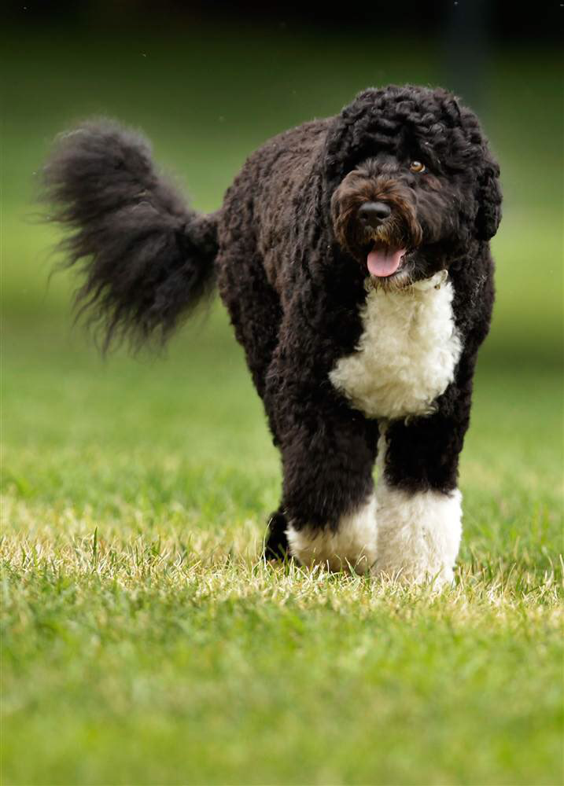

Here's an image of cute hairy BO